# Question 1

Feedforward Process: Building a ReLU neural network

## Question 1.1

Draw a network with 2 inputs, 1 hidden layer with 3 units, and 1-class binary output

[figure not shown]

Image produced using http://alexlenail.me/NN-SVG/index.html

## Question 1.2

Write out the mathematical equation for the output of this network (feel free to break the input-output relationship into multiple equations).

The expressions for the output from the hidden units are: $$ h_1 = max\left(\sum_{i=1}^{2} x_{i}w_{i1}, 0\right) $$ $$ h_2 = max\left(\sum_{i=1}^{2} x_{i}w_{i2}, 0\right) $$ $$ h_3 = max\left(\sum_{i=1}^{2} x_{i}w_{i3}, 0\right) $$

The expression for the binary output is: $$ \hat{y} = \frac{1}{1 + e^{-\left(\sum_{i=1}^{3} h_{i}v_{i}\right)}} $$

## Question 1.3

Write out the forward-pass function in python, call it ff nn ReLu(...)

```python
import numpy as np

# Activation Functions
sigmoid = lambda x: 1 / (1  + np.exp(-x))
relu = lambda x: np.maximum(x, 0)

# Forward Pass Function
def ff_nn__ReLU(x, W, b, V, c):

    hidden = relu(np.matmul(x, W) + b)
    out = sigmoid(np.matmul(hidden, V) + c)

    return out
```

## Question 1.4

Suppose you have the following set of weight matrices and inputs (see next cell) what are the class probabilities associated with the forward pass of each sample?

```python
# Weight matrices and inputs
W = np.matrix('1 -1 0 ; 0 0 0.5', dtype = float)
b = np.matrix('0 0 1', dtype = float)
V = np.matrix('1; 0; -1', dtype = float)
c = np.matrix('1', dtype = float)
X = np.matrix('1 -1; 0 -1; 0 1', dtype = float)
```

```python
ff_nn__ReLU(X, W, b, V, c)
```

```
matrix([[0.81757448],
        [0.62245933],
        [0.37754067]])
```

# Question 2

Gradient Decent Process

Consider a simple non-convex function of two variables:

$f(x,y)=(1-x^{3}) + 100(y^{2} - x)^{2}$

## Question 2.1

What are the partial derivatives of f with respect to x and to y?\

The partial derivative with respect to x: $$ \frac{\partial f}{\partial x} = \frac{\partial}{\partial x} (1-x^{3}) + 100(y^{2} - x)^{2}$$ $$ = (1) \frac{\partial}{\partial x} 1-x^{3} + (200(y^{2} - x)) \frac{\partial}{\partial x} y^{2} - x)$$ $$ = (1)(-3x^{2}) + (200(y^{2} - x))(-1)$$ $$ = -3x^{2} - 200(y^{2} - x)$$

The partial derivative with respect to y: $$ \frac{\partial f}{\partial y} = \frac{\partial}{\partial y} (1-x^{3}) + 100(y^{2} - x)^{2}$$ $$ = (1) \frac{\partial}{\partial x} 1-x^{3} + (200(y^{2} - x)) \frac{\partial}{\partial x} y^{2} - x)$$ $$ = (1) (0 - 0) + (200(y^{2} - x))(2y - 0)$$ $$ = (2y)(200)(y^{2} - x)$$ $$ = 400y(y^{2} - x)$$

## Question 2.2

Create a visualization of the contours of this function.

```python
# Libraries
from mpl_toolkits import mplot3d
%matplotlib inline
import numpy as np
import matplotlib.pyplot as plt
```

```python
# Setup

f = lambda x, y: (1-x**3) + 100 * (y**2 - x)**2

x = np.linspace(-2, 2, 100)
y = np.linspace(-2, 2, 100)
X, Y = np.meshgrid(x, y)

Z = f(X, Y)
```

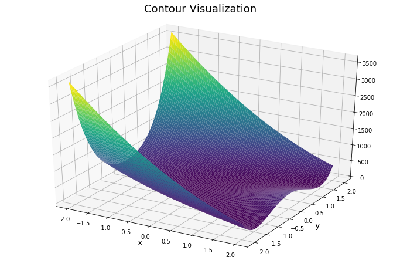

```python
# Contour Plotting
fig = plt.figure(figsize = (12, 8))
ax = plt.axes(projection='3d')
ax.plot_surface(X, Y, Z, rstride=1, cstride=1, cmap='viridis', edgecolor='none')
ax.set_title('Contour Visualization\n', fontsize = 18);
ax.set_xlabel('x', fontsize = 14)
ax.set_ylabel('y', fontsize = 14)
plt.show()
```

## Question 2.3

Write a Gradient Descent algorithm for finding the minimum of the function. Visualize your results with a few different learning rates.

```python
# Setup
trajectories = []
lr = [0.001, 0.0005, 0.00001]
n_iter = 1000

def grad_f(x, y):

    dfdx = -3 * x**2 - 200 * (y**2 - x)
    dfdy = 400 * y * (y**2 - x)

    return np.array([dfdx, dfdy])
```

```python
# Gradient Descent
for i in lr:

    x, y = -1.5, 1.5

    trajectories.append((i, x, y, f(x,y)))

    for j in range(0, n_iter):
        grad = grad_f(x, y)
        x = x - i * grad[0]
        y = y - i * grad[1]
        trajectories.append((i, x, y, f(x,y)))

# Reformat collected trajectories for use
traj = np.array(trajectories)
```

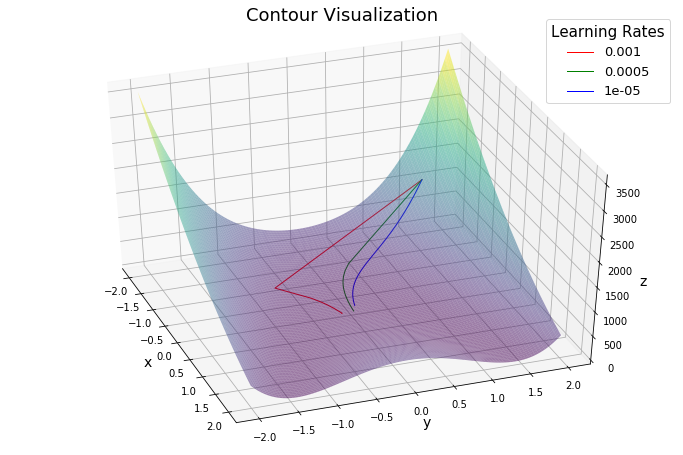

```python
# Learning Rate Plotting
fig = plt.figure(figsize = (12, 8))
ax = plt.axes(projection='3d')
ax.plot_surface(X, Y, Z, rstride=1, cstride=1, cmap='viridis', edgecolor='none', alpha = 0.5)
ax.set_title('Contour Visualization\n', fontsize = 18);
ax.set_xlabel('x', fontsize = 14)
ax.set_ylabel('y', fontsize = 14)
ax.set_zlabel('z', fontsize = 14)

list_colors = ['red', 'green', 'blue']

for i, line_color in zip(lr, list_colors):
    indexes = np.isin(traj[:,0], i)                                             # Look in first col of traj for lr = i
    temp = traj[indexes]                                                        # Collect the trajectories for the line
    ax.plot(temp[:, 1], temp[:, 2], temp[:, 3], color = line_color, lw = 1)     # Plot the line

ax.legend(lr, title = "Learning Rates", title_fontsize = 15, fontsize = 13)

ax.view_init(40, -20)
plt.show()
```

Above you can see the affect of 3 different learning rates on the path down the loss surface. For ease of comparison, the starting point of each descent was scheduled to start at x = -1.5, y = 1.5 and z = f(x,y).

## Question 2.4

Write a Gradient Descent With Momentum algorithm for finding the minimum. Visualize your results with a few different settings of the algorithm’s hyperparameters.

```python
# Setup
trajectories = []
lr = [0.001, 0.0005, 0.00001]
momentum = [.35, .2, .1]
n_iter = 1000
velocity = np.array([0.0, 0.0])

legend_entries = []

for i in lr:
    for j in momentum:
        legend_entries.append('LR = ' + str(i) + "   Mom = " + str(j))
```

```python
def grad_f(x, y):

    dfdx = -3 * x**2 - 200 * (y**2 - x)
    dfdy = 400 * y * (y**2 - x)

    return np.array([dfdx, dfdy])

# Gradient Descent
for epsilon in lr:
    for alpha in momentum:

        x, y = -1.5, 1.5

        trajectories.append((epsilon, alpha, x, y, f(x,y)))

        for j in range(0, n_iter):
            grad = grad_f(x, y)
            velocity = alpha * velocity - epsilon * grad
            x = x + velocity[0]
            y = y + velocity[1]
            trajectories.append((epsilon, alpha, x, y, f(x,y)))

# Reformat collected trajectories for use
traj = np.array(trajectories)
```

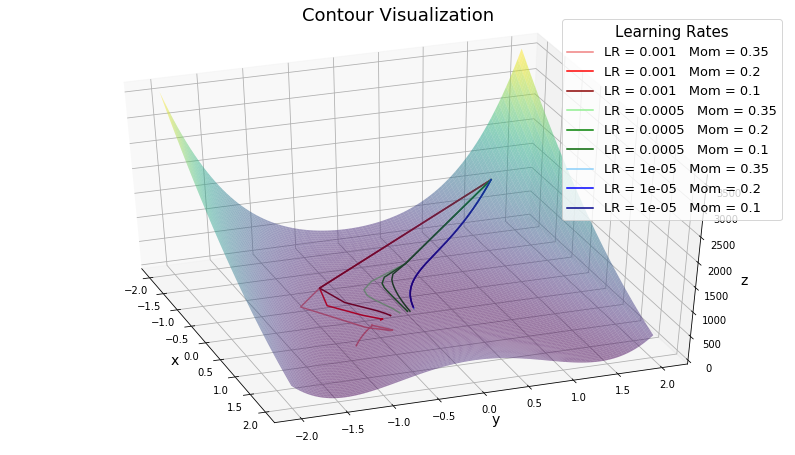

```python
# Plot
fig = plt.figure(figsize = (14, 8))
ax = plt.axes(projection='3d')
ax.plot_surface(X, Y, Z, rstride=1, cstride=1, cmap='viridis', edgecolor='none', alpha = 0.5)
ax.set_title('Contour Visualization\n', fontsize = 18);
ax.set_xlabel('x', fontsize = 14)
ax.set_ylabel('y', fontsize = 14)
ax.set_zlabel('z', fontsize = 14)

list_colors = ['lightcoral', 'red', 'darkred', 'lightgreen', 'green', 'darkgreen', 'lightskyblue', 'blue', 'darkblue']

col_index = 0

for i in lr:

    first = np.isin(traj[:,0], i)
    second = traj[first]

    for j in momentum:
                                                                                        # Look in first col of traj for lr = i
        third = np.isin(second[:,1], j)
        temp = second[third]                                                            # Collect the trajectories for the line
        ax.plot(temp[:, 2], temp[:, 3], temp[:, 4], color = list_colors[col_index], lw = 1.5)         # Plot the line
        col_index += 1

ax.legend(legend_entries, title = "Learning Rates", title_fontsize = 15, fontsize = 13)

ax.view_init(40, -20)
```

Above you can see the combined results of Learning Rate and Momentum at a couple of levels. The combined effects of Momentum and Learning Rate are exagerated as expected, by higher rates of both. At the low end of learning rate, the momentum ends up having very little effect on the path.

# Question 3

Backprop in Action

## Question 3.1

For the same network as in Question 1, derive expressions of the gradient of the Loss function with respect to each of the model parameters.

For the purposes of this network, this equates to 13 parameters. The 6 weights associated with inputs to the hidden layer ($w_{ij}$), 3 weights associated with the hidden layer to the binary output ($v_{k}$), and 4 biases associated with each node in the hidden layer and the output layer. Additionally, I have chosen to represent the hidden layer as both $in_{h}$ and $out_{h}$

$$\frac{\partial L}{\partial v_{1}} = \frac{\partial L}{\partial \hat{y}} \frac{\partial \hat{y}}{\partial v_{1}} = \left(\frac{y_{i}}{\hat{y}} - \frac{1 - y_{i}}{1 - \hat{y_{i}}} \right) out_{1} $$$$\frac{\partial L}{\partial v_{2}} = \frac{\partial L}{\partial \hat{y}} \frac{\partial \hat{y}}{\partial v_{2}} = \left(\frac{y_{i}}{\hat{y}} - \frac{1 - y_{i}}{1 - \hat{y_{i}}} \right) out_{2} $$$$\frac{\partial L}{\partial v_{3}} = \frac{\partial L}{\partial \hat{y}} \frac{\partial \hat{y}}{\partial v_{3}} = \left(\frac{y_{i}}{\hat{y}} - \frac{1 - y_{i}}{1 - \hat{y_{i}}} \right) out_{3} $$$$\frac{\partial L}{\partial w_{11}} = \frac{\partial L}{\partial \hat{y}} \frac{\partial \hat{y}}{\partial out_{1}} \frac{\partial out_{1}}{\partial in_{1}} \frac{\partial in_{1}}{\partial w_{11}} = \left(\frac{y_{i}}{\hat{y}} - \frac{1 - y_{i}}{1 - \hat{y_{i}}} \right) v_{1} \left(\begin{cases} 0 &\text{in\(_{1}\) \(<0\)} \\1 &\text{in\(_{1}\) \(>0\)} \end{cases} \right) x_{1} $$$$\frac{\partial L}{\partial w_{12}} = \frac{\partial L}{\partial \hat{y}} \frac{\partial \hat{y}}{\partial out_{2}} \frac{\partial out_{2}}{\partial in_{2}} \frac{\partial in_{2}}{\partial w_{12}} = \left(\frac{y_{i}}{\hat{y}} - \frac{1 - y_{i}}{1 - \hat{y_{i}}} \right) v_{2} \left(\begin{cases} 0 &\text{in\(_{2}\) \(<0\)} \\1 &\text{in\(_{2}\) \(>0\)} \end{cases} \right) x_{1} $$$$\frac{\partial L}{\partial w_{13}} = \frac{\partial L}{\partial \hat{y}} \frac{\partial \hat{y}}{\partial out_{3}} \frac{\partial out_{3}}{\partial in_{3}} \frac{\partial in_{3}}{\partial w_{13}} = \left(\frac{y_{i}}{\hat{y}} - \frac{1 - y_{i}}{1 - \hat{y_{i}}} \right) v_{3} \left(\begin{cases} 0 &\text{in\(_{3}\) \(<0\)} \\1 &\text{in\(_{3}\) \(>0\)} \end{cases} \right) x_{1} $$$$\frac{\partial L}{\partial w_{21}} = \frac{\partial L}{\partial \hat{y}} \frac{\partial \hat{y}}{\partial out_{1}} \frac{\partial out_{1}}{\partial in_{1}} \frac{\partial in_{1}}{\partial w_{21}} = \left(\frac{y_{i}}{\hat{y}} - \frac{1 - y_{i}}{1 - \hat{y_{i}}} \right) v_{1} \left(\begin{cases} 0 &\text{in\(_{1}\) \(<0\)} \\1 &\text{in\(_{1}\) \(>0\)} \end{cases} \right) x_{2} $$$$\frac{\partial L}{\partial w_{22}} = \frac{\partial L}{\partial \hat{y}} \frac{\partial \hat{y}}{\partial out_{2}} \frac{\partial out_{2}}{\partial in_{2}} \frac{\partial in_{2}}{\partial w_{22}} = \left(\frac{y_{i}}{\hat{y}} - \frac{1 - y_{i}}{1 - \hat{y_{i}}} \right) v_{2} \left(\begin{cases} 0 &\text{in\(_{2}\) \(<0\)} \\1 &\text{in\(_{2}\) \(>0\)} \end{cases} \right) x_{2} $$$$\frac{\partial L}{\partial w_{23}} = \frac{\partial L}{\partial \hat{y}} \frac{\partial \hat{y}}{\partial out_{3}} \frac{\partial out_{3}}{\partial in_{3}} \frac{\partial in_{3}}{\partial w_{23}} = \left(\frac{y_{i}}{\hat{y}} - \frac{1 - y_{i}}{1 - \hat{y_{i}}} \right) v_{3} \left(\begin{cases} 0 &\text{in\(_{3}\) \(<0\)} \\1 &\text{in\(_{3}\) \(>0\)} \end{cases} \right) x_{2} $$$$\frac{\partial L}{\partial c} = \frac{\partial L}{\partial \hat{y}} \frac{\partial \hat{y}}{\partial c} = \left(\frac{y_{i}}{\hat{y}} - \frac{1 - y_{i}}{1 - \hat{y_{i}}} \right) (1) $$$$\frac{\partial L}{\partial b_{1}} = \frac{\partial L}{\partial \hat{y}} \frac{\partial \hat{y}}{\partial out_{1}} \frac{\partial out_{1}}{\partial in_{1}} \frac{\partial in_{1}}{\partial b_{1}} = \left(\frac{y_{i}}{\hat{y}} - \frac{1 - y_{i}}{1 - \hat{y_{i}}} \right) v_{1} \left(\begin{cases} 0 &\text{in\(_{1}\) \(<0\)} \\1 &\text{in\(_{1}\) \(>0\)} \end{cases} \right) (1) $$$$\frac{\partial L}{\partial b_{2}} = \frac{\partial L}{\partial \hat{y}} \frac{\partial \hat{y}}{\partial out_{2}} \frac{\partial out_{2}}{\partial in_{2}} \frac{\partial in_{2}}{\partial b_{2}} = \left(\frac{y_{i}}{\hat{y}} - \frac{1 - y_{i}}{1 - \hat{y_{i}}} \right) v_{2} \left(\begin{cases} 0 &\text{in\(_{2}\) \(<0\)} \\1 &\text{in\(_{2}\) \(>0\)} \end{cases} \right) (1) $$$$\frac{\partial L}{\partial b_{3}} = \frac{\partial L}{\partial \hat{y}} \frac{\partial \hat{y}}{\partial out_{3}} \frac{\partial out_{3}}{\partial in_{3}} \frac{\partial in_{3}}{\partial b_{3}} = \left(\frac{y_{i}}{\hat{y}} - \frac{1 - y_{i}}{1 - \hat{y_{i}}} \right) v_{3} \left(\begin{cases} 0 &\text{in\(_{3}\) \(<0\)} \\1 &\text{in\(_{3}\) \(>0\)} \end{cases} \right) (1) $$

## Question 3.2

Write a function grad f(...) that takes in a weights vector and returns the gradient of the Loss at that location.

```python
def grad_f(X, Y, W, V, b, c):


    h_in = np.matmul(X, W) + b
    h_out = relu(h_in)
    y_hat = sigmoid(np.matmul(h_out, V) + c)

    y_hat = np.where(y_hat == 0.0, 0.00001, y_hat)

    dL_dy = - ((Y / y_hat) - ((1 - Y) / (1 - y_hat)))

    dy_hat_dv_1 = h_out[0, 0]
    dy_hat_dv_2 = h_out[0, 1]
    dy_hat_dv_3 = h_out[0, 2]

    dy_hat_dout1 = V[0]
    dy_hat_dout2 = V[1]
    dy_hat_dout3 = V[2]

    dout1_din1 = np.where(h_in[0,0] <= 0, 0, h_in[0,0])
    dout2_din2 = np.where(h_in[0,1] <= 0, 0, h_in[0,1])
    dout3_din3 = np.where(h_in[0,2] <= 0, 0, h_in[0,2])

    din1_dw11 = X[0,0]
    din2_dw12 = X[0,0]
    din3_dw13 = X[0,0]

    din1_dw21 = X[0,1]
    din2_dw22 = X[0,1]
    din3_dw23 = X[0,1]


    dL_dv1 = dL_dy * dy_hat_dv_1
    dL_dv2 = dL_dy * dy_hat_dv_2
    dL_dv3 = dL_dy * dy_hat_dv_3

    dL_dw11 = dL_dy * dy_hat_dout1 * dout1_din1 * din1_dw11
    dL_dw12 = dL_dy * dy_hat_dout2 * dout2_din2 * din2_dw12
    dL_dw13 = dL_dy * dy_hat_dout3 * dout3_din3 * din3_dw13

    dL_dw21 = dL_dy * dy_hat_dout1 * dout1_din1 * din1_dw21
    dL_dw22 = dL_dy * dy_hat_dout2 * dout2_din2 * din2_dw22
    dL_dw23 = dL_dy * dy_hat_dout3 * dout3_din3 * din3_dw23

    dL_dc = dL_dy

    dL_db1 = dL_dy * dy_hat_dout1 * dout1_din1
    dL_db2 = dL_dy * dy_hat_dout2 * dout2_din2
    dL_db3 = dL_dy * dy_hat_dout3 * dout3_din3

    return [dL_dv1, dL_dv2, dL_dv3, dL_dw11, dL_dw12, dL_dw13, dL_dw21, dL_dw22, dL_dw23, dL_dc, dL_db1, dL_db2, dL_db3]
```

The above function is terribly inefficient, but I ran out of time to create and test a more streamlined matrix based solution. That said, it works and given reasonable parameter choices, it displays pretty good learning.

## Question 3.3

Generate a synthetic dataset like the XOR pattern (see below).

```python
# Create a Dataset
Xs = np.random.uniform(low = -1.0, high = 1.0, size = 1000).reshape((1000,1))
Ys = np.random.uniform(low = -1.0, high = 1.0, size = 1000).reshape((1000,1))
Zs = np.logical_xor(Xs < 0, Ys > 0).reshape((1000,1))

XOR = np.concatenate((Xs, Ys, Zs), axis = 1)
```

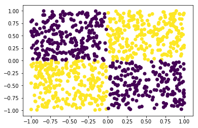

```python
plt.scatter(Xs, Ys, c = Zs)
plt.show()
```

## Question 3.4

Fit your network using Gradient Descent. Keep track of the total Loss at each iteration and plot the result.

First, I need to set up a loss function and some initial random values.

I'm making deep copies of the matrices, so that I can start from the same initial weights for better comparison against gradient descent and gradient descent with momentum.

```python
def loss(y, y_hat):
    return np.mean(np.multiply(-y, np.log(y_hat)) - np.multiply((1 - y), np.log(1 - y_hat)))

W = np.random.rand(2,3)
V = np.random.rand(3,1)
b = np.random.rand(1,3)
c = np.random.rand(1,1)

from copy import deepcopy
W1 = deepcopy(W)
V1 = deepcopy(V)
b1 = deepcopy(b)
c1 = deepcopy(c)
```

```
Iter: 250   Loss: 0.670089308339523
Iter: 500   Loss: 0.662707660160761
Iter: 750   Loss: 0.6559989264150569
Iter: 1000   Loss: 0.6497316274269657
Iter: 1250   Loss: 0.6360067887536834
Iter: 1500   Loss: 0.6121581233618172
Iter: 1750   Loss: 0.5654086601527056
Iter: 2000   Loss: 0.5335580473907612
Iter: 2250   Loss: 0.48114616617259287
Iter: 2500   Loss: 0.40487563612724364
Iter: 2750   Loss: 0.32221213355119394
Iter: 3000   Loss: 0.2576317090026148
Iter: 3250   Loss: 0.21023128805099917
Iter: 3500   Loss: 0.1717792411403005
Iter: 3750   Loss: 0.14163527439767606
```

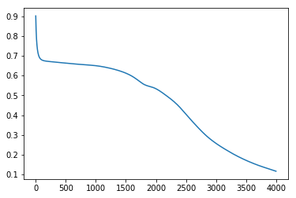

```python
def grad_descent(XOR, iters, lr, W, V, b, c):

    X_train = XOR[:, 0:2]
    y_train = XOR[:, 2: ]

    losses = []

    for iteration in range(iters):
        if iteration > 0 and iteration % 250 == 0:
            print ("Iter: " + str(iteration) + "   Loss: " + str(losses[iteration - 1]))

        for i in range(800):
            # print(i)
            gradient_vec = grad_f(X_train[i,:].reshape(1,2), y_train[i, :].reshape(1,1), W, V, b, c)

            V[0] = V[0] - lr * gradient_vec[0][0]
            V[1] = V[1] - lr * gradient_vec[1][0]
            V[2] = V[2] - lr * gradient_vec[2][0]
            W[0,0] = W[0,0] - lr * gradient_vec[3][0]
            W[0,1] = W[0,1] - lr * gradient_vec[4][0]
            W[0,2] = W[0,2] - lr * gradient_vec[5][0]
            W[1,0] = W[1,0] - lr * gradient_vec[6][0]
            W[1,1] = W[1,1] - lr * gradient_vec[7][0]
            W[1,2] = W[1,2] - lr * gradient_vec[8][0]
            c = c - lr * gradient_vec[9][0]
            b[0,0] = b[0,0] - lr * gradient_vec[10][0]
            b[0,1] = b[0,1] - lr * gradient_vec[11][0]
            b[0,2] = b[0,2] - lr * gradient_vec[12][0]


        temp = ff_nn__ReLU(X_train, W, b, V, c)
        losses.append(loss(y_train, temp))

    return losses

losses_grad = grad_descent(XOR, 4000, 0.00001, W1, V1, b1, c1)

plt.plot(losses_grad)
plt.show()
```

## Question 3.5

Repeat the exercise above using Momentum. Comment on whether your algorithm seems to converge more efficiently.

```
Iter: 250   Loss: 0.6669989776001318
Iter: 500   Loss: 0.6574530417683637
Iter: 750   Loss: 0.6491190556545535
Iter: 1000   Loss: 0.6392791443256632
Iter: 1250   Loss: 0.6189707864150801
Iter: 1500   Loss: 0.578339803839403
Iter: 1750   Loss: 0.5298338059914639
Iter: 2000   Loss: 0.4760369366080205
Iter: 2250   Loss: 0.39889079891454654
Iter: 2500   Loss: 0.3134234201734774
Iter: 2750   Loss: 0.24872055506134338
Iter: 3000   Loss: 0.19906080673776863
Iter: 3250   Loss: 0.15787015343426888
Iter: 3500   Loss: 0.1242098806264957
Iter: 3750   Loss: 0.09235437203198071
```

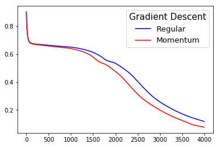

```python
def momentum_descent(XOR, iters, lr, alpha, W, V, b, c):

    X_train = XOR[0:800,0:2]
    y_train = XOR[0:800,2:]

    losses = []
    velocity = np.array([0.0, 0.0, 0.0, 0.0, 0.0, 0.0, 0.0, 0.0, 0.0, 0.0, 0.0, 0.0, 0.0])

    for iteration in range(iters):

        for i in range(800):
            # print(i)
            gradient_vec = grad_f(X_train[i,:].reshape(1,2), y_train[i, :].reshape(1,1), W, V, b, c)

            velocity = alpha * velocity - lr * np.array(gradient_vec).reshape(1,13)

            V[0] = V[0] + velocity[0,0]
            V[1] = V[1] + velocity[0,1]
            V[2] = V[2] + velocity[0,2]
            W[0,0] = W[0,0] + velocity[0,3]
            W[0,1] = W[0,1] + velocity[0,4]
            W[0,2] = W[0,2] + velocity[0,5]
            W[1,0] = W[1,0] + velocity[0,6]
            W[1,1] = W[1,1] + velocity[0,7]
            W[1,2] = W[1,2] + velocity[0,8]
            c = c + velocity[0,9]
            b[0,0] = b[0,0] + velocity[0,10]
            b[0,1] = b[0,1] + velocity[0,11]
            b[0,2] = b[0,2] + velocity[0,12]


        temp = ff_nn__ReLU(X_train, W, b, V, c)
        losses.append(loss(y_train, temp))

        if iteration > 0 and iteration % 250 == 0:
            print ("Iter: " + str(iteration) + "   Loss: " + str(losses[iteration]))

    return losses

# Start from the same weights as regular gradient descent to see if it converges more quickly

W1 = deepcopy(W)
V1 = deepcopy(V)
b1 = deepcopy(b)
c1 = deepcopy(c)

losses_momentum = momentum_descent(XOR, 4000, 0.00001, 0.1, W1, V1, b1, c1)

plt.plot(losses_grad, color = "blue")
plt.plot(losses_momentum, color = "red")
plt.legend(["Regular", "Momentum"], title = "Gradient Descent", title_fontsize = 15, fontsize = 13)
plt.show()
```

Above you can see both the regular version of gradient descent and gradient descent with momentum converge over time. I started both with the same weights to enable a more accurate comparison of their efficiency in convergence. It's apparent that the momentum ends up improving the performance and allows it to converge for efficiently.

## Question 3.6

Plot a visualization of the final decision boundary that your model has learned. Overlay the datapoints in this plot.

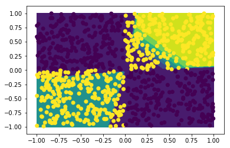

```python
x = np.linspace(-1, 1, 250).reshape(250,1)
y = np.linspace(-1, 1, 250).reshape(250,1)
Z = np.zeros(250 * 250).reshape(250,250)

for countx, i in enumerate(x):
    for county, j in enumerate(y):
        # print("x = " + str(i))
        # print("y = " + str(j))
        temp = np.array([i[0],j[0]])
        Z[countx][county] = ff_nn__ReLU(np.array([i[0],j[0]]), W1, b1, V1, c1)

X, Y = np.meshgrid(x, y)

plt.contourf(X,Y,Z)
plt.scatter(Xs, Ys, c = Zs)
plt.show()
```

Above you can see the decision boundaries for the dataset and how they line up with the actual dataset. While there is still some difference visible, with more iterations it is likely that the decision boundary would have gotten tighter.